# Order Statistic Deliverable

Dong Chen

10-19

# 1 Introduction

We want to know which quantiles of a continuous distribution can one estimate with more precision?

## 1.1 Background

The median is an important quantity in data analysis. It represents the middle value of the data distribution. Estimates of the median, however, have a degree of uncertainty because (a) the estimates are calculated from a finite sample and (b) the data distribution of the underlying data is generally unknown. One important roles of a data scientist is to quantify and to communicate the degree of uncertainty in his or her data analysis.

I will write a blog post to answer a series of questions related to the variation of the median (and a range of other quantiles)

# 2 Methods

## 2.1 Questions

**Q:** Begin with the median from a sample of *N* = 200 from the standard normal distribution. Write an R function that is the density function for the median in this sample. Note that the 100th order statistic is approximately the median, and use the order statistic formula discussed in class. Generate a plot of the function.

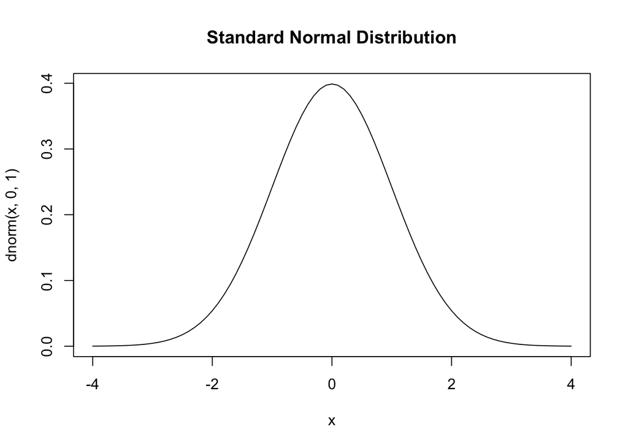

```r
dorder <- function(x,n,k){
  k*choose(n,k)*(pnorm(x))^(k-1)*(1-pnorm(x))^(n-k)*dnorm(x)
}

x <- seq(-4,4,by=0.1)
plot(x,dnorm(x,0,1),type = "l",main = "Standard Normal Distribution")
```

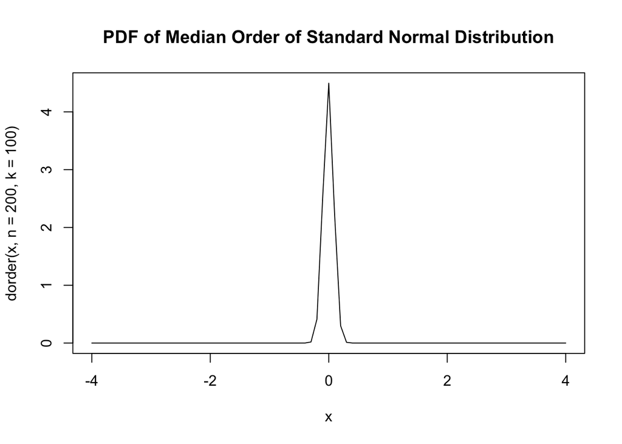

```r
plot(x,dorder(x,n=200,k=100),type = "l",main = "PDF of Median Order of Standard Normal Distribution")
```

This figure is PDF of Median Order of Standard Normal Distribution. The figure is much higher at close to 0 than elsewhere. It shows means mainly concentrate at 0.

**Q:** Write an R function that is the probability function for the median in this sample. Use the order statistic formula discussed in class. Generate a plot of the function.

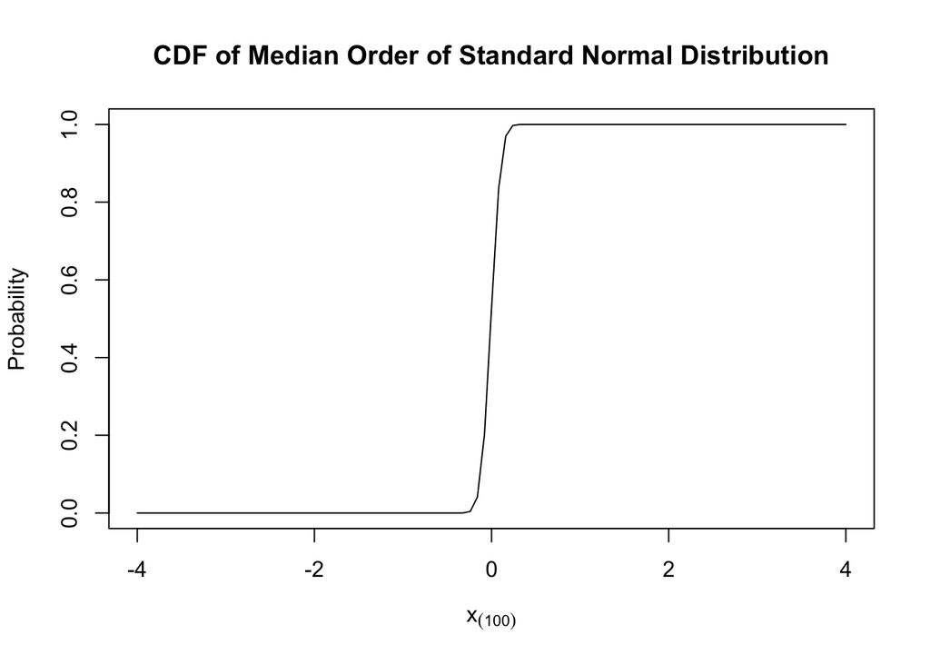

```r
porder <- function(x,n,k){
  pbinom(k-1,n,pnorm(x,0,1),lower.tail = F)
}

curve(porder(x,n=200,k=100),-4,4,xlab=parse(text="x[(100)]"),ylab=("Probability"),main = "CDF of Median Order of Standard Normal Distribution")
```

Here is the CDF of Median Order of Standard Normal Distribution and it growth rapidly near 0.

**Q:** Write an R function that is the quantile function for the median in this sample. (You have several options for how to write this function.) Generate a plot of the function.

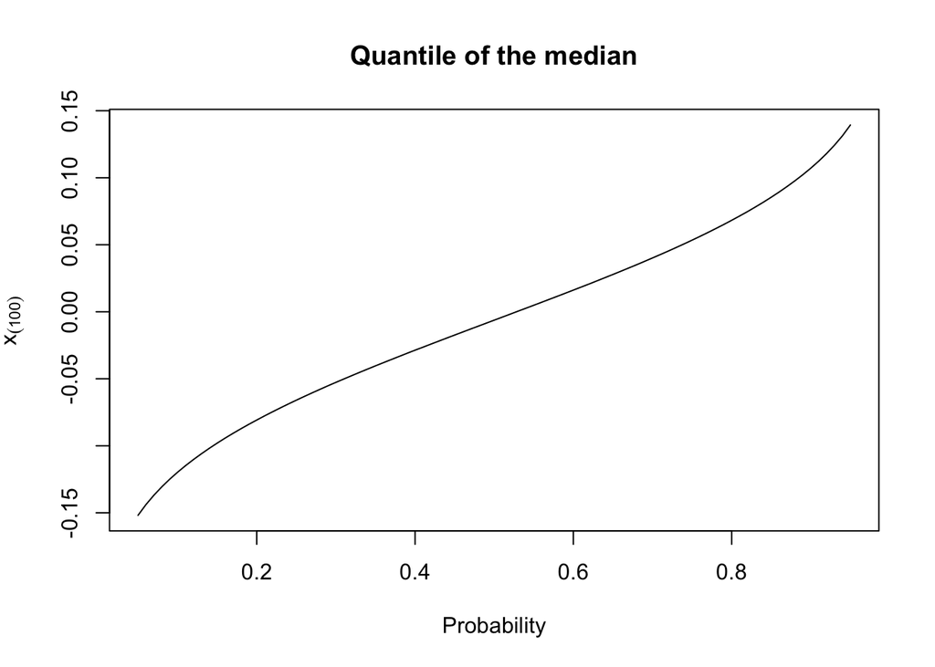

```r
qorder <- function(p,n,k){
  out <- p
  for(i in seq_along(p)){
    out[i] <- uniroot(function(x){porder(x,n,k)-p[i]},c(-100,100))$root
  }
  out
}

p <- seq(0.05,0.95,by=0.01)
plot(p,qorder(p,200,100),type = "l",ylab=parse(text="x[(100)]"),xlab=("Probability"),main = "Quantile of the median")
```

Here is quantile of the median.

**Q:** Simulate the sampling distribution for the median. Create a plot of the empirical CDF (ECDF). Overlay the plot of the ECDF with a plot of the CDF.

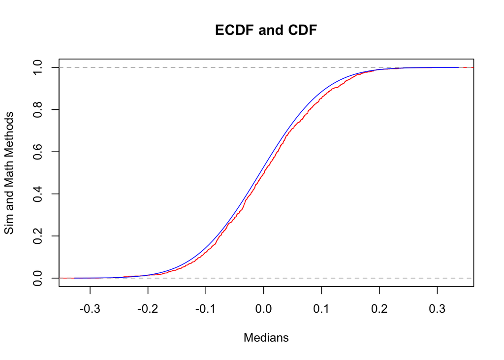

```r
sim_median <- NA
for (i in 1:1000) {
  sim_median[i] <- median(rnorm(200))
}
sim_median_ecdf <- ecdf(sim_median)
plot(sim_median_ecdf, do.points = FALSE, col = "red", main = "ECDF and CDF", xlab = "Medians", ylab = "Sim and Math Methods")
curve(porder(x,k=100,n=200), add = TRUE, col = "blue")
```

Here is the difference between ECDF and CDF.

**Q:** Using the simulated sampling distribution from the previous question, create a histogram (on the density scale). Overlay the histogram with a plot of the density function.

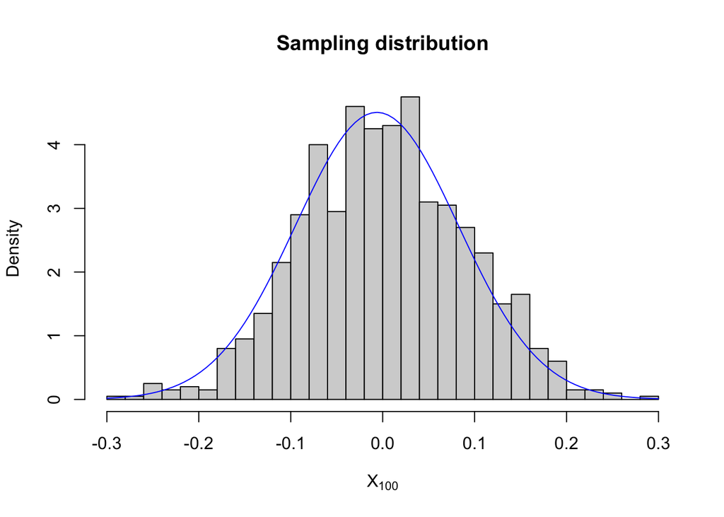

```r
hist(sim_median, breaks = 30, col = "lightgray", freq = FALSE,
     xlab = parse(text = "X[100]"), ylab = "Density", main = "Sampling distribution")
curve(dorder(x,n=200,k=100),add = TRUE, xlab="Median",ylab = "Density",col = "blue")
```

Here is the histogram and the density plot.

**Q:** One very common way to compare a random sample to a theoretical candidate distribution is the QQ plot. It is created by ploting quantiles of the theoretical distribution on the x-axis and empirical quantiles from the sample on the y-axis.

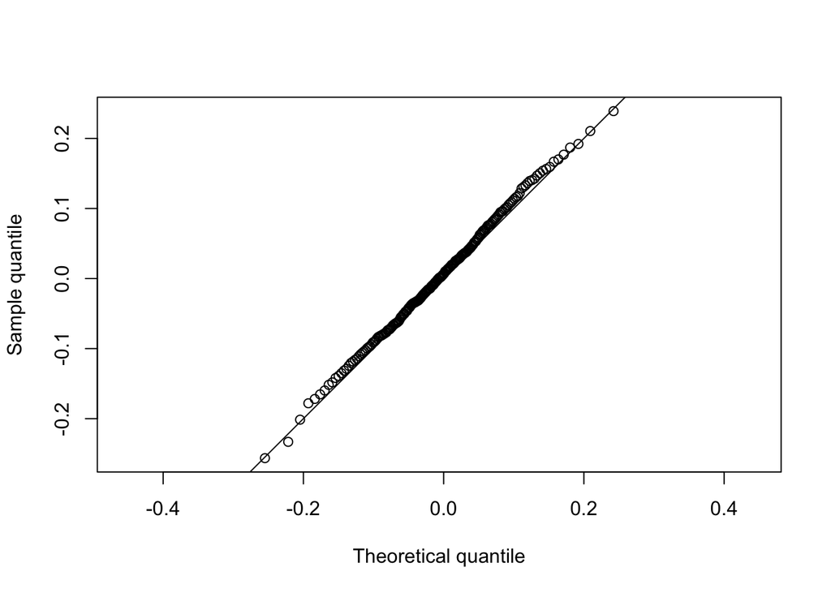

```r
p <- ppoints(200)
x <- qorder(p,n=200,k=100)
y <- quantile(sim_median, probs = p)

plot(x,y, asp = 1, xlab = "Theoretical quantile", ylab = "Sample quantile")
abline(0,1)
```

Sample mean fits a straight line with y=x. We can say that the sample quantile fits the theoretical quantile.

**Q:** Modify the `dorder`, `porder`, and `qorder` functions so that the functions take a new parameter `k` (for the *k*<sup>*th*</sup> order statistic) so that the functions will work for any order statistic and not just the median.

```r
#dorder
dorder <- function(x,n,k){
  k*choose(n,k)*(pnorm(x))^(k-1)*(1-pnorm(x))^(n-k)*dnorm(x)
}

#porder
porder <- function(x,n,k){
  pbinom(k-1,n,pnorm(x,0,1),lower.tail = F)
}

#qorder
qorder <- function(p,n,k){
  out <- p
  for(i in seq_along(p)){
    out[i] <- uniroot(function(x){porder(x,n,k)-p[i]},c(-100,100))$root
  }
  out
}
```

This is just the functions I used, if we want to get the *k*<sup>*th*</sup> order statistic, just need to set a new k.

**Q:** Generate the QQ plot for simulated data from the sampling distribution of the sample max and the theoretical largest order statistic distribution.

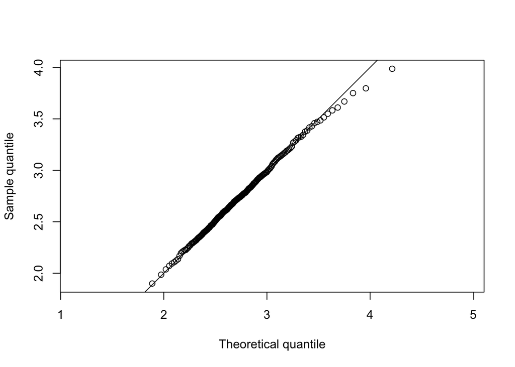

```r
sim_max <- NA
for (i in 1:1000) {
  sim_max[i] <- max(rnorm(200))
}


p <- ppoints(200)
x <- qorder(p,n=200,k=200)
y <- quantile(sim_max, probs = p)

plot(x,y, asp = 1, xlab = "Theoretical quantile", ylab = "Sample quantile")
abline(0,1)
```

Sample max fits a straight line with y=x. We can say that the sample quantile fits the theoretical quantile.

**Q:** Modify the `dorder`, `porder`, and `qorder` functions so that the functions take new parameters `dist` and `...` so that the functions will work for any continuous distribution that has `d` and `p` functions defined in R.

Ref: https://cran.r-project.org/web/views/Distributions.html

These are continuous distribution that has `d` and `p` functions defined in R.

```r
#dorder
dorder_all <- function(x,n,k,dist="norm", ...){
  pf <- get(paste0("p",dist))
  df <- get(paste0("d",dist))
  k*choose(n,k)*(pf(x,...))^(k-1)*(1-pf(x, ...))^(n-k)*df(x, ...)
}

#porder
porder_all <- function(x,n,k,dist="norm", ...){
  pf <- get(paste0("p",dist))
  df <- get(paste0("d",dist))
  pbinom(k-1,n,pf(x, ...),lower.tail = F)
}

#qorder
qorder_all <- function(p,n,k,dist="norm", ...){
  pf <- get(paste0("p",dist))
  df <- get(paste0("d",dist))
  out <- p
  for(i in seq_along(p)){
    out[i] <- uniroot(function(x){porder_all-p[i]},c(-100,100))$root
  }
  out
}
```

If we want to change the function, just need to change `dist` to functions we need.

**Q:** Use the newly modified functions to plot the probability and density functions for the sample min (*N* = 200).

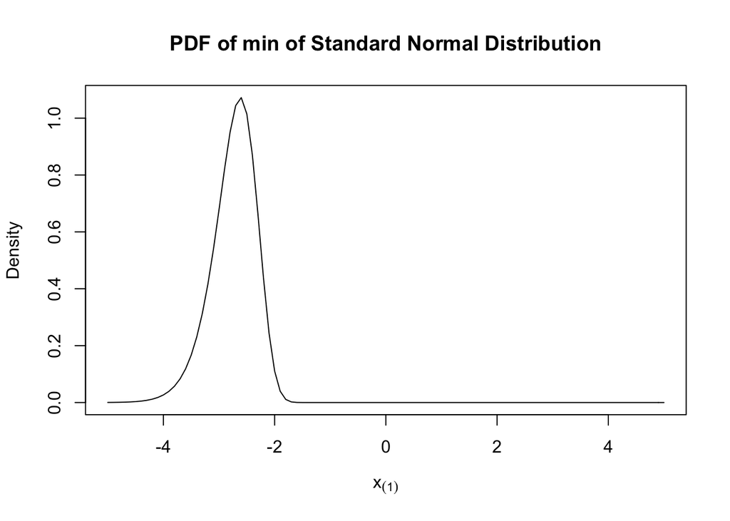

```r
curve(dorder_all(x,n=200,k=1,dist="norm"),-5,5,xlab=parse(text="x[(1)]"),ylab=("Density"),main = "PDF of min of Standard Normal Distribution")
```

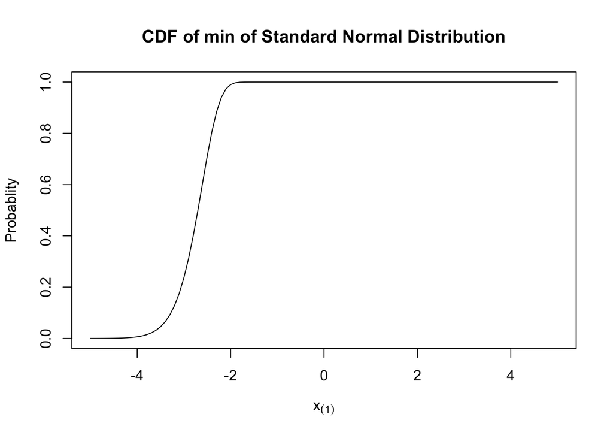

```r
curve(porder_all(x,n=200,k=1,dist="norm"),-5,5,xlab=parse(text="x[(1)]"),ylab=("Probablity"),main = "CDF of min of Standard Normal Distribution")
```

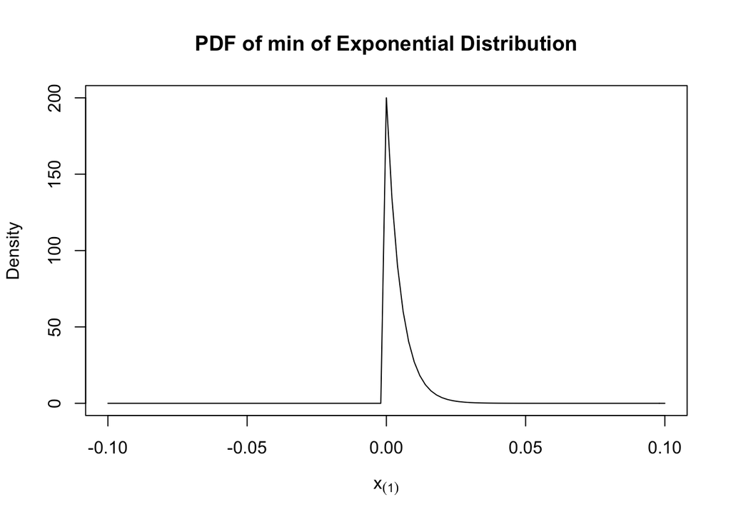

```r
curve(dorder_all(x,n=200,k=1,dist="exp"),-0.1,0.1,xlab=parse(text="x[(1)]"),ylab=("Density"),main = "PDF of min of Exponential Distribution")
```

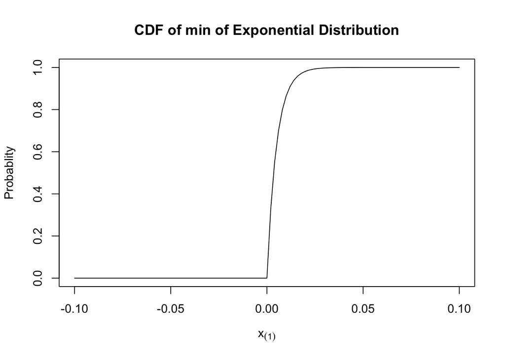

```r
curve(porder_all(x,n=200,k=1,dist="exp"),-0.1,0.1,xlab=parse(text="x[(1)]"),ylab=("Probablity"),main = "CDF of min of Exponential Distribution")
```

I use Standard Normal Distribution and Exponential Distribution to try the function in Q9